# Coronavirus Exploratory Data Analysis

Hayat Hussein

2024-03-11

# Introduction

Covid-19 or more formally known as the Coronavirus is an infectious disease that has been caused by the SARS-CoV2 virus. This virus spreads by liquid particles traveling through the air through people coughing, sneezing, speaking, or breathing. This virus can travel from person to person by an infected person’s mouth, or nose. The symptoms of this virus include “fever, cough, tiredness, loss of taste and smell, sore throat, and headaches” (WHO 2024). Preventative measures that can be taken to prevent covid-19 are receiving vaccination, social distancing from one another, wearing a mask, washing your hands regularly, and isolating from others when feeling sick. Communities at a higher risk of this disease include older people, people with cardiovascular and chronic diseases, cancer, and diabetes. Other communities at risk include “People who are immunocompromised, have certain disabilities, or have underlying health conditions” (CDC 2023).

# Data Cleaning/Preparation

The data cleaning and preparation steps taken to prepare the data set include importing the coronavirus and comorbid excel sheets. After importing the sheets, I next merged the two data sets, keeping all columns and rows they both had using the full join statement. After that, I re-coded ages equal to or greater than 120 to NA in order to make the dataset more efficient and remove any outliers that might skew the data. Finally, I re-coded the ‘Mainland China’ value to ‘China’ in order to keep consistent records throughout the data. By taking these measures, I was able to fix errors and have consistent data throughout the code as well as ensure the efficiency of my code.

```r
# import libraries
library(dplyr)
library(readxl)

coronavirus <- read_excel("coronavirus.xlsx")
comorbidity <- read_excel("comorbidity.xlsx")


# merge the two datasets
full_j <- full_join(coronavirus, comorbidity, by="ID")
str(full_j)
```

```
## tibble [1,783 × 12] (S3: tbl_df/tbl/data.frame)
##  $ ID         : num [1:1783] 1632 1594 103 17 36 ...
##  $ Sex        : chr [1:1783] "F" "M" "F" "F" ...
##  $ DOB        : POSIXct[1:1783], format: "1949-04-05" "1949-09-15" ...
##  $ Race       : chr [1:1783] "White" "White" "White" "White" ...
##  $ Ethnicity  : chr [1:1783] "Not Hispanic" "Hispanic" "Not Hispanic" "Not Hispanic" ...
##  $ FName      : chr [1:1783] "Doris" "Carmen" "Sandra" "Patricia" ...
##  $ LName      : chr [1:1783] "THOMPSON" "JACKSON" "HERNANDEZ" "JACKSON" ...
##  $ CoronaVirus: num [1:1783] 0 1 0 0 0 1 1 1 1 0 ...
##  $ Age        : num [1:1783] 300 200 123 87 55 55 55 55 55 55 ...
##  $ Country    : chr [1:1783] "Mainland China" "Mainland China" "US" "UK" ...
##  $ Death      : num [1:1783] 0 1 0 0 0 1 0 0 0 0 ...
##  $ Comorbidity: chr [1:1783] "None" "None" "None" NA ...
```

```r
# recoding age 120>=
full_j$Age[full_j$Age >=120] <- NA

str(full_j)
```

```
## tibble [1,783 × 12] (S3: tbl_df/tbl/data.frame)
##  $ ID         : num [1:1783] 1632 1594 103 17 36 ...
##  $ Sex        : chr [1:1783] "F" "M" "F" "F" ...
##  $ DOB        : POSIXct[1:1783], format: "1949-04-05" "1949-09-15" ...
##  $ Race       : chr [1:1783] "White" "White" "White" "White" ...
##  $ Ethnicity  : chr [1:1783] "Not Hispanic" "Hispanic" "Not Hispanic" "Not Hispanic" ...
##  $ FName      : chr [1:1783] "Doris" "Carmen" "Sandra" "Patricia" ...
##  $ LName      : chr [1:1783] "THOMPSON" "JACKSON" "HERNANDEZ" "JACKSON" ...
##  $ CoronaVirus: num [1:1783] 0 1 0 0 0 1 1 1 1 0 ...
##  $ Age        : num [1:1783] NA NA NA 87 55 55 55 55 55 55 ...
##  $ Country    : chr [1:1783] "Mainland China" "Mainland China" "US" "UK" ...
##  $ Death      : num [1:1783] 0 1 0 0 0 1 0 0 0 0 ...
##  $ Comorbidity: chr [1:1783] "None" "None" "None" NA ...
```

```r
# recoding values of Mainland China to China
full_j <- mutate(full_j, Country = ifelse(Country == "Mainland China", "China", Country))

table(full_j$Country)
```

```
##
##            Australia              Belgium               Brazil
##                   85                   16                    1
##             Cambodia               Canada                China
##                   22                   60                  872
##                Egypt              Finland               France
##                    4                   20                   25
##              Germany            Hong Kong                India
##                   22                   26                   19
##                Italy          Ivory Coast                Japan
##                   19                    1                   30
##                Macau             Malaysia               Mexico
##                   25                   25                    1
##                Nepal              Nigeria               Others
##                   24                    1                   12
##          Philippines               Russia            Singapore
##                   20                   18                   27
##          South Korea                Spain            Sri Lanka
##                   28                   18                   22
##               Sweden               Taiwan             Thailand
##                   18                   26                   31
##                   UK United Arab Emirates                   US
##                   22                   24                  186
##              Vietnam
##                   26
```

# Exploratory Data Analysis

```r
# finding the number of observations
nrow(full_j)
```

```
## [1] 1783
```

```r
# finding the number of variables
select(full_j)
```

```
## # A tibble: 1,783 × 0
```

```r
colnames(full_j)
```

```
##  [1] "ID"          "Sex"         "DOB"         "Race"        "Ethnicity"
##  [6] "FName"       "LName"       "CoronaVirus" "Age"         "Country"
## [11] "Death"       "Comorbidity"
```

```r
# percentage of patients that are female
prop.table(table(full_j$Sex == 'F'))['TRUE']*100
```

```
##     TRUE
## 49.88739
```

```r
# median age of patients who have coronavirus
median(full_j$Age, na.rm = T)
```

```
## [1] 29
```

```r
# mean age and sd of patients who died from coronavirus
mean(full_j$Age[full_j$Death == TRUE], na.rm = T)
```

```
## [1] 28.3908
```

```r
sd(full_j$Age[full_j$Death == TRUE], na.rm = T)
```

```
## [1] 15.94183
```

```r
# among patients who have covid, what percentage are from each of the following countries: China, Italy, and the US
China <- prop.table(table(full_j$Country[full_j$CoronaVirus ==TRUE] == 'China')) ['TRUE'] *100
table(China)
```

```
## China
## 51.1389521640091
##                1
```

```r
Italy <- prop.table(table(full_j$Country[full_j$CoronaVirus ==TRUE] == 'Italy')) ['TRUE'] *100
table(Italy)
```

```
## Italy
## 0.455580865603645
##                 1
```

```r
US <- prop.table(table(full_j$Country[full_j$CoronaVirus ==TRUE] == 'US')) ['TRUE'] *100
table(US)
```

```
## US
## 10.0227790432802
##                1
```

```r
# comorbidities associated with patients who have coronavirus
 prop.table(table(full_j$Comorbidity[full_j$CoronaVirus ==TRUE]))*100
```

```
##
## Heart Disease           HIV Liver Disease         Lupus          None
##      3.885714      7.542857      1.942857     15.314286     71.314286
```

# Data Visualization

The boxplot illustrates a pink boxplot that compares the Age distribution by the Coronavirus variable, comparing the people who have the virus and those who do not have the virus by their ages. The x-axis represents the Age and the y-axis represents whether or not the patient has the CoronaVirus (1 if the patient has, 0 if the patient does not). This boxplot is presented horizontally.

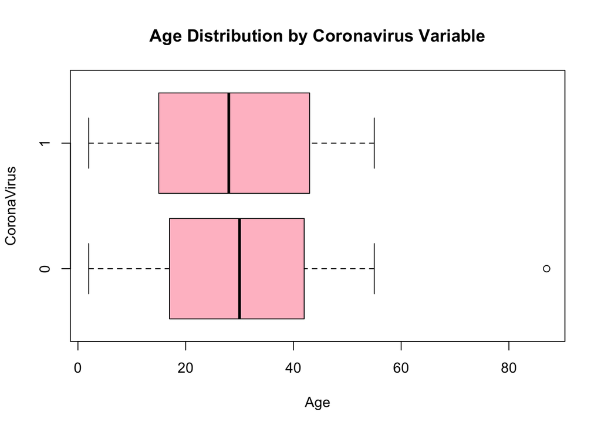

```r
boxplot(full_j$Age~full_j$CoronaVirus, main="Age Distribution by Coronavirus Variable", xlab="Age", ylab="CoronaVirus", col="pink", horizontal = TRUE)
```

# References

Centers for Disease Control and Prevention. (2023). About COVID-19. Centers for Disease Control and Prevention. https://www.cdc.gov/coronavirus/2019-ncov/your-health/about-covid-19.html

WHO. (2021). Coronavirus Disease (COVID-19). World Health Organization. https://www.who.int/health-topics/coronavirus#tab=tab_1